# mpl_toolkits.mplot3d.axes3d.Axes3D.voxels

**Axes3D.voxels([*x*, *y*, *z*, ]*/*, *filled*, *facecolors=None*, *edgecolors=None*, **kwargs)[[source]](https://github.com/matplotlib/matplotlib/blob/v3.9.2/lib/mpl_toolkits/mplot3d/axes3d.py#L3067-L3274)**

Plot a set of filled voxels

All voxels are plotted as 1x1x1 cubes on the axis, with `filled[0, 0, 0]` placed with its lower corner at the origin. Occluded faces are not plotted.

**Parameters:**

**filled**3D np.array of bool**

A 3D array of values, with truthy values indicating which voxels to fill

**x, y, z**3D np.array, optional**

The coordinates of the corners of the voxels. This should broadcast to a shape one larger in every dimension than the shape of *filled*. These can be used to plot non-cubic voxels.

If not specified, defaults to increasing integers along each axis, like those returned by [`indices()`](https://numpy.org/doc/stable/reference/generated/numpy.indices.html#numpy.indices). As indicated by the `/` in the function signature, these arguments can only be passed positionally.

**facecolors, edgecolors**array-like, optional**

The color to draw the faces and edges of the voxels. Can only be passed as keyword arguments. These parameters can be:

- A single color value, to color all voxels the same color. This can be either a string, or a 1D RGB/RGBA array
- `None`, the default, to use a single color for the faces, and the style default for the edges.
- A 3D [`ndarray`](https://numpy.org/doc/stable/reference/generated/numpy.ndarray.html#numpy.ndarray) of color names, with each item the color for the corresponding voxel. The size must match the voxels.
- A 4D [`ndarray`](https://numpy.org/doc/stable/reference/generated/numpy.ndarray.html#numpy.ndarray) of RGB/RGBA data, with the components along the last axis.

**shade**bool, default: True**

Whether to shade the facecolors.

**lightsource**`LightSource`, optional**

The lightsource to use when *shade* is True.

**kwargs**

Additional keyword arguments to pass onto `Poly3DCollection`.

**Returns:**

**faces**dict**

A dictionary indexed by coordinate, where `faces[i, j, k]` is a `Poly3DCollection` of the faces drawn for the voxel `filled[i, j, k]`. If no faces were drawn for a given voxel, either because it was not asked to be drawn, or it is fully occluded, then `(i, j, k) not in faces`.

#### Examples

([`Source code`](https://matplotlib.org/stable/_downloads/bffc095eda0f4f626d1da8c97178afcd/voxels.py), [`2x.png`](https://matplotlib.org/stable/_downloads/ed3ca699d0936f93e02e8dab45c613a2/voxels.2x.png), [`png`](https://matplotlib.org/stable/_downloads/c0ed58bf65809d814831b728e0db7d25/voxels.png))

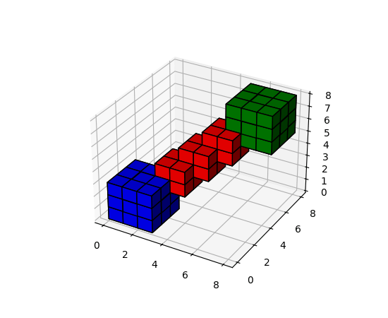

([`Source code`](https://matplotlib.org/stable/_downloads/cdcfc69294110306faf86b32bd593a70/voxels_rgb.py), [`2x.png`](https://matplotlib.org/stable/_downloads/10a3ba800e8e3311f3746aeb2cdd3f20/voxels_rgb.2x.png), [`png`](https://matplotlib.org/stable/_downloads/9fbccfe21023a64a80d31af0abbbd353/voxels_rgb.png))

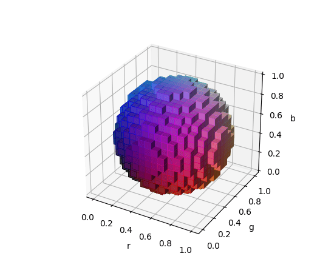

([`Source code`](https://matplotlib.org/stable/_downloads/a22680c5161cae0bae86cebf2222cb71/voxels_torus.py), [`2x.png`](https://matplotlib.org/stable/_downloads/cde10f8f0f9c24df818bc19a2106422a/voxels_torus.2x.png), [`png`](https://matplotlib.org/stable/_downloads/e0445eda062f33b65131276980fdfab7/voxels_torus.png))

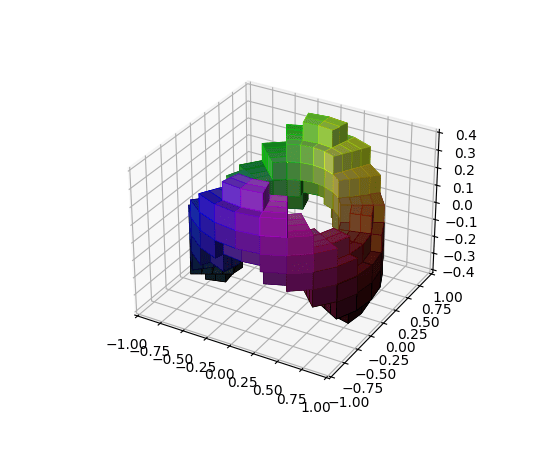

([`Source code`](https://matplotlib.org/stable/_downloads/3eef910ce113b73e9aaad84106d6a280/voxels_numpy_logo.py), [`2x.png`](https://matplotlib.org/stable/_downloads/2bffca7b60ef81c9abb32cc7fbbb0803/voxels_numpy_logo.2x.png), [`png`](https://matplotlib.org/stable/_downloads/4a625b8a05dbe5a5055c42b6351cb360/voxels_numpy_logo.png))

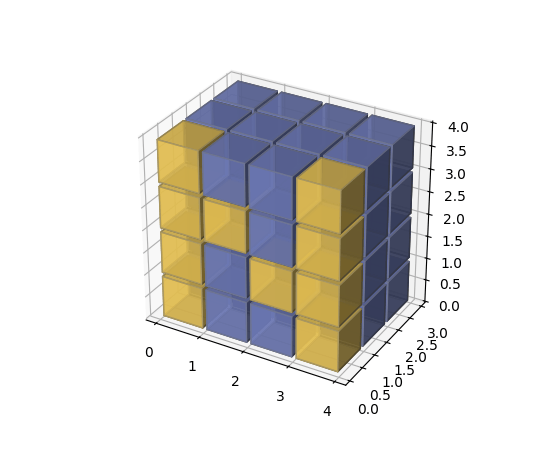

## Examples using `mpl_toolkits.mplot3d.axes3d.Axes3D.voxels`

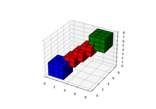

[3D voxel / volumetric plot](https://matplotlib.org/stable/gallery/mplot3d/voxels.html#sphx-glr-gallery-mplot3d-voxels-py)

3D voxel / volumetric plot

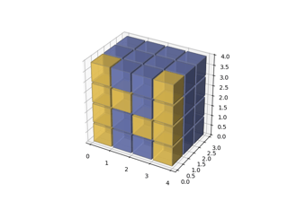

[3D voxel plot of the NumPy logo](https://matplotlib.org/stable/gallery/mplot3d/voxels_numpy_logo.html#sphx-glr-gallery-mplot3d-voxels-numpy-logo-py)

3D voxel plot of the NumPy logo

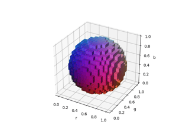

[3D voxel / volumetric plot with RGB colors](https://matplotlib.org/stable/gallery/mplot3d/voxels_rgb.html#sphx-glr-gallery-mplot3d-voxels-rgb-py)

3D voxel / volumetric plot with RGB colors

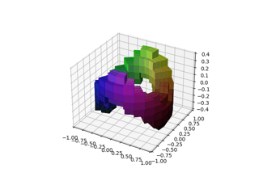

[3D voxel / volumetric plot with cylindrical coordinates](https://matplotlib.org/stable/gallery/mplot3d/voxels_torus.html#sphx-glr-gallery-mplot3d-voxels-torus-py)

3D voxel / volumetric plot with cylindrical coordinates

[figure not shown]

[voxels([x, y, z], filled)](https://matplotlib.org/stable/plot_types/3D/voxels_simple.html#sphx-glr-plot-types-3d-voxels-simple-py)

voxels([x, y, z], filled)